# Global Patterns of Measles Incedece: Associations with Seasonal Trends and Urban Population Rates

# Why Measles and Why Now?

In May of 2025, the United States’ total number of measles cases reached the second highest case count in 25 years according to the Centers for Disease Control and Prevention. Jen Richmond curated two of the data sets we used in order to look at the global trends of measles and rubella cases since 2012.

# Global Measles and Rubella Data

The data set created by Richmond came from the World Health Organization’s Provisional monthly measles and rubella data on June 12, 2025. Both data set contains information on number of suspected, clinical, confirmed and total cases of both measles and rubella per year for countries around the world. One data set also includes all of this information for the months of each year included in the first data set. Looking at this data led us to our first research question, do certain months of the year tend to have a higher amount of suspected measles cases, for different countries?

# Association Between Months of the Year and Suspected Measles Cases

In order to see if there is an association between months of the year and suspected measles cases, we decided to start by looking at one country at a time. We created a table looking at the mean amount of suspected measles cases per month for China, from 2012 to 2025. The table also includes a column showing how far away a typical month’s number of suspected measles cases tends to differ from the mean.

```r
top_pop <- cases_year |>
  group_by(region) |>
  slice_max(order_by = total_population, n = 1, with_ties = FALSE)

top_pop_month <- left_join(top_pop, cases_month, by = "country")

summ_sus_measles_per_month <- function(country_name){
  country_data <- top_pop_month |>
    filter(country == country_name)

  summ_sus_measles <- tibble()

  for(mon in 1:12) {
    mon_data <- country_data |>
      filter(month == mon)

    summ_sus_measles <- bind_rows(summ_sus_measles, tibble(
      country = country_name,
      month = month.name[mon],
      mean = mean(mon_data$measles_suspect, na.rm = TRUE),
      SD = sd(mon_data$measles_suspect, na.rm = TRUE)
    ))
  }

  return(summ_sus_measles)
}

#summ_sus_measles_per_month("Nigeria")
#summ_sus_measles_per_month("UnitedStatesofAmerica")
#summ_sus_measles_per_month("Pakistan")
#summ_sus_measles_per_month("RussianFederation")
#summ_sus_measles_per_month("India")
china_sum <- summ_sus_measles_per_month("China")

china_sum |>
  select(-country) |>
  gt() |>
  fmt_number(columns = c(mean, SD),
             decimals = 2) |>
  tab_style(
    style = cell_text(weight = "bold"),
    locations = cells_column_labels()
    ) |>
  tab_header(
    title = md("Summary of Suspected Measles Cases per Month for China")
  ) |>
  tab_caption(
    caption = md("Table 1")
  ) |>
  cols_label(month = "Month",
             mean = "Mean",
             SD = "Standard Deviation") |>
  tab_spanner(
    label = "Summary Statistics",
    columns = c(mean, SD)
  ) |>
  data_color(
    method = "numeric",
    palette = "Spectral",
    reverse = TRUE
  )
```

Table 1

Summary of Suspected Measles Cases per Month for China

| Month | Summary Statistics Mean | Summary Statistics Standard Deviation |
| --- | --- | --- |
| January | 2,493.21 | 2,169.59 |
| February | 3,156.79 | 3,344.38 |
| March | 5,898.00 | 5,067.43 |
| April | 7,451.79 | 6,394.32 |
| May | 8,382.15 | 6,273.26 |
| June | 6,228.62 | 3,832.52 |
| July | 4,160.46 | 1,968.46 |
| August | 3,239.77 | 1,051.48 |
| September | 2,913.77 | 465.04 |
| October | 3,390.69 | 672.83 |
| November | 3,801.08 | 591.91 |
| December | 4,147.33 | 1,120.24 |

The information in Table 1 only summarizes the average number of suspected measles’s cases per month for one country, China. This allows us to see that some months seem to have a much higher amount of suspected measles cases than others. To see if other countries also have differing amounts of suspected measles cases, we can look at Figure 1:

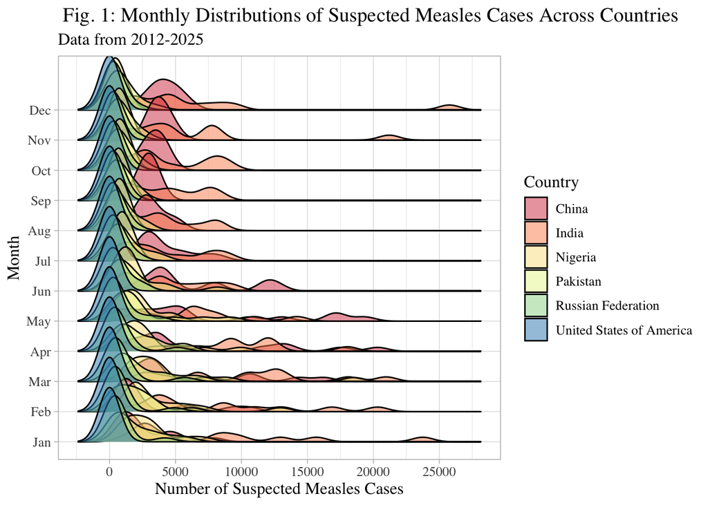

```r
top_pop <- cases_year |>
  group_by(region) |>
  slice_max(order_by = total_population, n = 1, with_ties = FALSE)

top_pop_month <- left_join(top_pop, cases_month, by = "country")

top_pop_month$month <- factor(top_pop_month$month,
                              levels = 1:12,
                              labels = c("Jan", "Feb", "Mar","Apr",                                          "May","Jun", "Jul", "Aug",                                          "Sep", "Oct", "Nov", "Dec"))

ggplot(data = top_pop_month,
       mapping = aes(x = measles_suspect,
                     y = month,
                     fill = country)) +
  geom_density_ridges(alpha = 0.5) +
  labs(x = "Number of Suspected Measles Cases",
       y = "Month",
       fill = "Country",
       title = " Fig. 1: Monthly Distributions of Suspected Measles Cases Across Countries",
       subtitle = "Data from 2012-2025") +
  scale_x_continuous(breaks = seq(0, 30000, 5000)) +
  scale_fill_brewer(palette = "Spectral") +
  theme_light() +
  theme(text = element_text(family = "Times", size = 12))
```

# Is Measles Associated with Only Months?

After investigating the association between months of the year and suspected measles cases, we wondered if there was anything else that could effect the incident rate of measles. As measles is known to be more prevalent in developing countries, we thought that it could be possible that the urban population rate of a country could be associated with its measles incident rate.

# Urban Population Rate Data

In order to investigate this association, we needed to bring in more data. We came across an API from API ninjas, an API provider who gets their data from a network of vetted sources and vendors. The original API contains a multitude of demographic and geographic information on countries around the world, but for our purposes we chose to focus on urban population rate. We combined our previous measles and rubella data set containing only information for cases per year and an API containing information on countries’ urban population rates. With this new data set, we were able to analyze our second curiosity: is the incident rate of measles cases associated with a country’s urban population rate?

# Rural-Urban Classification and Measles Incident Rate

We began by classifying each country as either highly urbanized, mixed, or primarily rural. Then, we were able to create a table showing the average incident rate of measles per classification, as well as how much a specific country’s measles incident rate tended to differ from this average.

```r
urban_type_incident <- function(country_iso3) {

  cases_year_urban_pop_df |>
    filter(iso3 == country_iso3) |>
    mutate(urban_type = ifelse(
      urban_population > 80,
      "Highly Urbanized",
      ifelse(urban_population > 50,
             "Mixed",
             "Primarily Rural"))
      ) |>
    summarise(iso3 = country_iso3,
              urban_type = first(urban_type),
              mean_incident =
                mean(measles_incidence_rate_per_1000000_total_population)
              )

}

urban_type_df <- map_dfr(cases_year_urban_pop_df$iso3, urban_type_incident)


urban_pop_type_df <- cases_year_urban_pop_df |>
  left_join(urban_type_df, by = "iso3") |>
  select(c(iso3, urban_population, urban_type,
           measles_incidence_rate_per_1000000_total_population,
           mean_incident))

urban_pop_type_df |>
  group_by(urban_type) |>
  summarise(mean_by_type = mean(
    measles_incidence_rate_per_1000000_total_population),
    sd_by_type = sd(
      measles_incidence_rate_per_1000000_total_population)) |>
  gt() |>
  fmt_number(columns = c(mean_by_type, sd_by_type),
             decimals = 2) |>
  tab_style(
    style = cell_text(weight = "bold"),
    locations = cells_column_labels()
    ) |>
  tab_header(
    title = md("Summary of Mean Measle's Incident Rate by Rural-Urban Classification")
  ) |>
  tab_caption(
    caption = md("Table 2")
  ) |>
  cols_label(urban_type = "Classification",
             mean_by_type = "Mean",
             sd_by_type = "Standard Deviation") |>
  tab_spanner(
    label = "Summary Statistics",
    columns = c(mean_by_type, sd_by_type)
  )
```

Table 2

Summary of Mean Measle’s Incident Rate by Rural-Urban Classification

| Classification | Summary Statistics Mean | Summary Statistics Standard Deviation |
| --- | --- | --- |
| Highly Urbanized | 15.77 | 61.53 |
| Mixed | 59.58 | 410.01 |
| Primarily Rural | 68.65 | 362.25 |

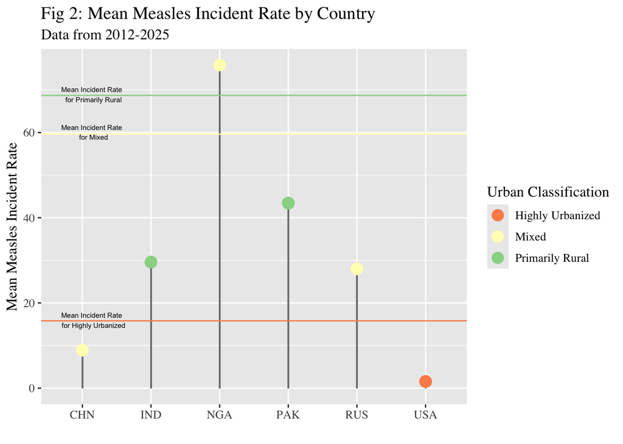

```r
urban_pop_type_df2 <- urban_pop_type_df |>
  group_by(urban_type) |>
  summarise(mean_by_type = mean(
    measles_incidence_rate_per_1000000_total_population,
    na.rm = T),
    sd_by_type = sd(
      measles_incidence_rate_per_1000000_total_population,
      na.rm = T))

urban_pop_type_df <- urban_pop_type_df |>
  left_join(urban_pop_type_df2, by = "urban_type") |>
  filter(iso3 == unique(top_pop_month$iso3.x))

ggplot(data = urban_pop_type_df,
       mapping = aes(x = iso3,
                     y = mean_incident,
                     color = urban_type)) +
  geom_segment(aes(yend = mean_incident,
                   x = iso3,
                   y = 0,
                   xend = iso3),
               color = "gray50") +
  geom_point(size = 4) +
  labs(y = "Mean Measles Incident Rate",
       x = "",
       title = "Fig 2: Mean Measles Incident Rate by Country",
       subtitle = "Data from 2012-2025",
       color = "Urban Classification") +
  geom_hline(yintercept = 15.8, color = "#FC8D59")  +
  annotate("text",
           x = 1.15,
           y = 16,
           label = "Mean Incident Rate \n for Highly Urbanized",
           size = 2) +
  geom_hline(yintercept = 59.6, color = "#FFFFBF") +
  annotate("text",
           x = 1.15,
           y = 60.1,
           label = "Mean Incident Rate \n for Mixed",
           size = 2) +
  geom_hline(yintercept = 68.7, color = "#99D594") +
  annotate("text",
           x = 1.15,
           y = 68.9,
           label = "Mean Incident Rate \n for Primarily Rural",
           size = 2) +
  scale_color_brewer(palette = "Spectral") +
  theme_grey() +
  theme(text = element_text(family = "Times", size = 12))
```

# Combining Months and Urban Population Rate

After analyzing the association between measles, months, and urban population rates separately, we wanted to see how they months and urban population rates affect measles together. So, we created a linear model that estimates the proportion of total measles cases per month based on urban population rate, as shown in Table 3.

```r
merged <- left_join(
  measles_prop_month, urban_pop_type_df, by = "iso3")
```

```r
model_table <- model_df |>
  gt() |>
  tab_header(
    title = md("Multiple Linear Regression Model for Measles Proportion by Country and Year")
  ) |>
  tab_caption(
    caption = md("Table 3: Estimates of differences in measles proportion (relative to the reference country), in descending order")) |>

  tab_style(
    style = cell_text(weight = "bold"),
    locations = cells_column_labels()
  ) |>
  fmt_percent( columns = Estimate) |>
  cols_label(
    term = "Country",
    Estimate = "Estimate",
    `Std. Error` = "Std Error",
    `t value` = "t-value",
    `p value` = "p-value"
  ) |>
  fmt_number(columns = -c(term, Estimate),
             decimals = 4
  ) |>
  text_transform(
    locations = cells_body(columns = term),
    fn = function(x) {
      dplyr::recode(
        x,
        "(Intercept)" = "Baseline",
        "urban_population" = "Urban Population Rate"
      )
    }
  )

model_table
```

| Country | Estimate | Std Error | t-value | p-value |
| --- | --- | --- | --- | --- |
| Baseline | 116.20% | 0.0060 | 185.3100 | 0.0000 |
| Urban Population Rate | −0.70% | 0.0000 | −55.6000 | 0.0000 |

As seen by the very small p-values, we can see that urban population rate is a significant predictor of proportion of total measles cases per month. It is expected that with each one percent increase in urban population rate, the proportion of total measles cases will decrease by 0.7%. Thus, we can see that urban population rates and months of the year can both be important aspects of investigating measles incidents around the world.